# Large Seedling PIRI GLMM

Kathleen Stutzman

2024-01-04

## Introduction:

This script, originally written as an R script, will be much more readable as an R Markdown. Therefore, I am translating it into a markdown file.

# Pitch Pine Large Seedling GLMM code

Libraries:

```r
# libraries -------------------
library(dplyr)
library(tidyverse)
library(ggplot2)
library(lme4)
library(lmerTest)
library(glmmTMB)
library(TMB)
library(emmeans)
library(DHARMa)
```

Set working directory

```r
knitr::opts_knit$set(root.dir = '/Users/user/Desktop/Data/Regen_RProj/')
```

Functions:

```r
# functions -------------------
```

Global variables:

```r
# global variables -------------------
file_folder_LS <- "CleanData/largeseedling_CSV/"

options(scipen = 999) #to display actual values

file_names_LS <- list.files(path=file_folder_LS)
```

For loop to read in files:

```r
for (i in seq_along(file_names_LS)) {
  assign(paste0(file_names_LS[i], i),
         read.csv(paste0(file_folder_LS, file_names_LS[i])))
}

# Adding treatment types -------------------
LS_Control_Data.csv1$Treat_Type <- "Control"
LS_Fall_Burn_Data.csv2$Treat_Type <- "FallRx"
LS_Mow_Burn_Data.csv3$Treat_Type <- "MowRx"
LS_Spring_Burn_Data.csv4$Treat_Type <- "SpringRx"
LS_Thinned_Data.csv5$Treat_Type <- "Harvest"

# merge into one data set -------------------
large_seedling <- rbind(LS_Control_Data.csv1,
                        LS_Fall_Burn_Data.csv2,
                        LS_Mow_Burn_Data.csv3,
                        LS_Spring_Burn_Data.csv4,
                        LS_Thinned_Data.csv5)

# remove merged datasets to keep the envr clean -------------------
rm(LS_Control_Data.csv1,
   LS_Fall_Burn_Data.csv2,
   LS_Mow_Burn_Data.csv3,
   LS_Spring_Burn_Data.csv4,
   LS_Thinned_Data.csv5)
```

Creating groupings of species: PIRI, Shrub Oak, & Other:

```r
large_seedling$Species_Groups <- NA

# PIRI
large_seedling$Species_Groups <- ifelse(large_seedling$Species_Code == 'PIRI', 'PIRI', large_seedling$Species_Groups)

# Shrub Oak
large_seedling$Species_Groups <- ifelse(large_seedling$Species_Code %in% c('QUPR', 'QUIL'), 'Shrub Oak', large_seedling$Species_Groups)

# Other
large_seedling$Species_Groups <- ifelse(large_seedling$Species_Code %in% c('ACRU', 'QUCO', 'QUAL', 'QUVE', 'QURU', 'QUPA', 'SAAL', 'AMSP', 'BELE', 'BEPO', 'BENI', 'PODE', 'POGR', 'POTR', 'ACPE', 'FRAM', 'SAHU', 'FAGR', 'MASP', 'ACNE', 'CRSP', 'FRAL', 'ROPS', 'RHCA', 'ELUM', 'FRPE', 'PRSE', 'PRVI', 'PRPE', 'PIST', 'ABBA'), 'Other', large_seedling$Species_Groups)

# now to check that all species have been assigned and only NAs are NAs in new column -------------------
check_ls <- large_seedling %>%
  filter(if_any(Species_Groups, is.na))
```

Manipulate data to create a complete dataset, where implied zeros are now express and combined species groups totals are counted as one:

```r
# select for just the information I want
large_seedling <- large_seedling %>%
  select(Region,
         Treat_Type,
         Site,
         Plot_No,
         Species_Groups,
         Total,
         Browsed,
         StumpSprout)

#split treat type, site, region data off -------------------
large_seedling_meta <- large_seedling %>%
  select(Region, Treat_Type, Site, Plot_No) %>%
  distinct(Plot_No, .keep_all = TRUE)

large_seedling_plot <- large_seedling %>%
  select(Plot_No, Species_Groups, Total, Browsed, StumpSprout)

# duplicates of "other" need to be combined into one row before using complete -------------------
large_seedling_plot1 <- large_seedling_plot %>%
  group_by(Plot_No, Species_Groups) %>%
  summarise(Total = sum(Total),
            Browsed = sum(Browsed),
            StumpSprout = sum(StumpSprout)) %>%
  ungroup()
large_seedling_plot2 <- large_seedling_plot1 %>%
  complete(Plot_No, Species_Groups, fill = list(Total = 0, Browsed = 0, StumpSprout = 0))

# get rid of NAs -------------------
large_seedlingNA <- large_seedling_plot2[complete.cases(large_seedling_plot2),]

# now to join it back with the meta data -------------------
ls_merge <- merge(large_seedling_meta, large_seedlingNA, by = 'Plot_No')

#check for correct number of plots (1001)
n_distinct(ls_merge$Plot_No)
```

```
## [1] 1001
```

```r
# remove dataframes no longer needed -------------------
rm(check_ls,
   large_seedling,
   large_seedling_meta,
   large_seedling_plot,
   large_seedling_plot1,
   large_seedling_plot2,
   large_seedlingNA)
```

Now looking just at PIRI:

```r
# filter just for PIRI
ls_piri <- ls_merge %>%
  filter(Species_Groups == "PIRI") %>%
  arrange(Treat_Type)

# make explanatory variables factors -------------------
ls_piri$Treat_Type = factor(ls_piri$Treat_Type,
                              levels = unique(ls_piri$Treat_Type))

ls_piri$Region = factor(ls_piri$Region,
                          levels = unique(ls_piri$Region))

ls_piri$Site = factor(ls_piri$Site,
                        levels = unique(ls_piri$Site))
```

Import time since data and add it to the PIRI dataset

```r
time_since <- read_csv("CleanData/Treat_Year_Data.csv")
ls_piri <- merge(ls_piri, time_since, by = 'Site')
#log transform time from treatment data
ls_piri$l.TFT <- log(ls_piri$Time_from_Treat)
```

Run the ‘Add_BA’ script and merge with dataset (should probably clean this script)

```r
source("Scripts/Add_BA.R")
```

```r
# merge with ls dataset -------------------
ls.merge1 <- merge(ls_piri, prism_BA, by = "Plot_No")
```

Run ‘Ground_Data.R’ script and add it to PIRI dataset (should probably clean this as well)

```r
source("Scripts/Ground_Data.R")

# merge with ls dataset -------------------
ls_alldata <- merge(ls.merge1, ground3, by = "Plot_No")

rm(ls.merge1,
   ls_piri)
```

Hidden below are models with convergence problems:

Models that converge:

```r
ls.p5 <- glmer(Total~Treat_Type + avgLD_l + (1|Site/Plot_No),
               data = ls_alldata,
               family = poisson)
summary(ls.p5) #AIC is 284.4
```

```
## Generalized linear mixed model fit by maximum likelihood (Laplace
##   Approximation) [glmerMod]
##  Family: poisson  ( log )
## Formula: Total ~ Treat_Type + avgLD_l + (1 | Site/Plot_No)
##    Data: ls_alldata
##
##      AIC      BIC   logLik deviance df.resid
##    284.4    318.0   -134.2    268.4      490
##
## Scaled residuals:
##      Min       1Q   Median       3Q      Max
## -0.57666 -0.05464 -0.03589 -0.02703  1.66210
##
## Random effects:
##  Groups       Name        Variance Std.Dev.
##  Plot_No:Site (Intercept) 2.106    1.451
##  Site         (Intercept) 9.465    3.077
## Number of obs: 498, groups:  Plot_No:Site, 498; Site, 47
##
## Fixed effects:
##                    Estimate Std. Error z value Pr(>|z|)
## (Intercept)        -5.21302    1.84679  -2.823  0.00476 **
## Treat_TypeFallRx    1.00689    1.85362   0.543  0.58699
## Treat_TypeHarvest   3.63646    2.01442   1.805  0.07104 .
## Treat_TypeMowRx    -0.01713    1.81445  -0.009  0.99247
## Treat_TypeSpringRx  0.14680    2.04549   0.072  0.94279
## avgLD_l            -1.13444    0.51325  -2.210  0.02708 *
## ---
## Signif. codes:  0 '***' 0.001 '**' 0.01 '*' 0.05 '.' 0.1 ' ' 1
##
## Correlation of Fixed Effects:
##             (Intr) Tr_TFR Trt_TH Tr_TMR Tr_TSR
## Trt_TypFllR -0.578
## Trt_TypHrvs -0.569  0.522
## Trt_TypMwRx -0.634  0.575  0.527
## Trt_TypSprR -0.616  0.515  0.486  0.533
## avgLD_l     -0.379 -0.001 -0.028  0.129  0.076
```

```r
ls.p6 <- glmer(Total~Treat_Type + (1|Site/Plot_No),
               data = ls_alldata,
               family = poisson)
summary(ls.p6) #AIC is 287.5
```

```
## Generalized linear mixed model fit by maximum likelihood (Laplace
##   Approximation) [glmerMod]
##  Family: poisson  ( log )
## Formula: Total ~ Treat_Type + (1 | Site/Plot_No)
##    Data: ls_alldata
##
##      AIC      BIC   logLik deviance df.resid
##    287.5    317.0   -136.8    273.5      491
##
## Scaled residuals:
##      Min       1Q   Median       3Q      Max
## -0.58966 -0.04582 -0.03657 -0.02967  1.48728
##
## Random effects:
##  Groups       Name        Variance Std.Dev.
##  Plot_No:Site (Intercept) 2.475    1.573
##  Site         (Intercept) 8.621    2.936
## Number of obs: 498, groups:  Plot_No:Site, 498; Site, 47
##
## Fixed effects:
##                    Estimate Std. Error z value  Pr(>|z|)
## (Intercept)         -6.9647     1.6446  -4.235 0.0000229 ***
## Treat_TypeFallRx     1.0029     1.7965   0.558    0.5767
## Treat_TypeHarvest    3.4885     1.9464   1.792    0.0731 .
## Treat_TypeMowRx      0.4779     1.7589   0.272    0.7859
## Treat_TypeSpringRx   0.4259     1.9392   0.220    0.8262
## ---
## Signif. codes:  0 '***' 0.001 '**' 0.01 '*' 0.05 '.' 0.1 ' ' 1
##
## Correlation of Fixed Effects:
##             (Intr) Tr_TFR Trt_TH Tr_TMR
## Trt_TypFllR -0.636
## Trt_TypHrvs -0.633  0.532
## Trt_TypMwRx -0.650  0.583  0.541
## Trt_TypSprR -0.644  0.533  0.505  0.543
```

```r
#best model so far --------------------
ls.p7 <- glmer(Total~Treat_Type + avgLD_l+ (1|Site/Plot_No) + offset(l.TFT),
               data = ls_alldata,
               family = poisson)
summary(ls.p7) #AIC is 284.6
```

```
## Generalized linear mixed model fit by maximum likelihood (Laplace
##   Approximation) [glmerMod]
##  Family: poisson  ( log )
## Formula: Total ~ Treat_Type + avgLD_l + (1 | Site/Plot_No) + offset(l.TFT)
##    Data: ls_alldata
##
##      AIC      BIC   logLik deviance df.resid
##    284.6    318.3   -134.3    268.6      490
##
## Scaled residuals:
##      Min       1Q   Median       3Q      Max
## -0.58138 -0.05509 -0.03526 -0.02461  1.64404
##
## Random effects:
##  Groups       Name        Variance Std.Dev.
##  Plot_No:Site (Intercept) 2.096    1.448
##  Site         (Intercept) 9.908    3.148
## Number of obs: 498, groups:  Plot_No:Site, 498; Site, 47
##
## Fixed effects:
##                    Estimate Std. Error z value   Pr(>|z|)
## (Intercept)         -8.7211     1.8790  -4.641 0.00000346 ***
## Treat_TypeFallRx     2.8500     1.8887   1.509    0.13130
## Treat_TypeHarvest    5.7603     2.0504   2.809    0.00496 **
## Treat_TypeMowRx      2.1656     1.8475   1.172    0.24113
## Treat_TypeSpringRx   2.7377     2.1164   1.294    0.19581
## avgLD_l             -1.1665     0.5173  -2.255    0.02413 *
## ---
## Signif. codes:  0 '***' 0.001 '**' 0.01 '*' 0.05 '.' 0.1 ' ' 1
##
## Correlation of Fixed Effects:
##             (Intr) Tr_TFR Trt_TH Tr_TMR Tr_TSR
## Trt_TypFllR -0.570
## Trt_TypHrvs -0.562  0.519
## Trt_TypMwRx -0.630  0.572  0.527
## Trt_TypSprR -0.608  0.503  0.476  0.523
## avgLD_l     -0.388  0.000 -0.025  0.115  0.075
```

```r
ls.p8 <- glmer(Total~Treat_Type + l.Mineral + (1|Site/Plot_No) + offset(l.TFT),
               data = ls_alldata,
               family = poisson)
summary(ls.p8) #288
```

```
## Generalized linear mixed model fit by maximum likelihood (Laplace
##   Approximation) [glmerMod]
##  Family: poisson  ( log )
## Formula: Total ~ Treat_Type + l.Mineral + (1 | Site/Plot_No) + offset(l.TFT)
##    Data: ls_alldata
##
##      AIC      BIC   logLik deviance df.resid
##    288.0    321.7   -136.0    272.0      490
##
## Scaled residuals:
##      Min       1Q   Median       3Q      Max
## -0.58953 -0.05239 -0.03945 -0.02865  1.84578
##
## Random effects:
##  Groups       Name        Variance Std.Dev.
##  Plot_No:Site (Intercept) 2.158    1.469
##  Site         (Intercept) 9.278    3.046
## Number of obs: 498, groups:  Plot_No:Site, 498; Site, 47
##
## Fixed effects:
##                    Estimate Std. Error z value       Pr(>|z|)
## (Intercept)        -10.5084     1.6947  -6.201 0.000000000562 ***
## Treat_TypeFallRx     2.8216     1.8439   1.530        0.12596
## Treat_TypeHarvest    5.5265     2.0055   2.756        0.00586 **
## Treat_TypeMowRx      2.4896     1.8157   1.371        0.17031
## Treat_TypeSpringRx   2.8768     2.0218   1.423        0.15477
## l.Mineral            0.4117     0.2852   1.443        0.14888
## ---
## Signif. codes:  0 '***' 0.001 '**' 0.01 '*' 0.05 '.' 0.1 ' ' 1
##
## Correlation of Fixed Effects:
##             (Intr) Tr_TFR Trt_TH Tr_TMR Tr_TSR
## Trt_TypFllR -0.622
## Trt_TypHrvs -0.625  0.524
## Trt_TypMwRx -0.639  0.576  0.535
## Trt_TypSprR -0.635  0.520  0.495  0.532
## l.Mineral    0.032 -0.024 -0.059 -0.073 -0.077
```

Test value of offset variable:

```r
library(lmtest)
lrtest(ls.p7, ls.p5)
```

```
## Likelihood ratio test
##
## Model 1: Total ~ Treat_Type + avgLD_l + (1 | Site/Plot_No) + offset(l.TFT)
## Model 2: Total ~ Treat_Type + avgLD_l + (1 | Site/Plot_No)
##   #Df  LogLik Df  Chisq            Pr(>Chisq)
## 1   8 -134.28
## 2   8 -134.18  0 0.2041 < 0.00000000000000022 ***
## ---
## Signif. codes:  0 '***' 0.001 '**' 0.01 '*' 0.05 '.' 0.1 ' ' 1
```

```r
# with offset p is less than 0.0001, so keep it
```

Run DHARMa package to check model fit:

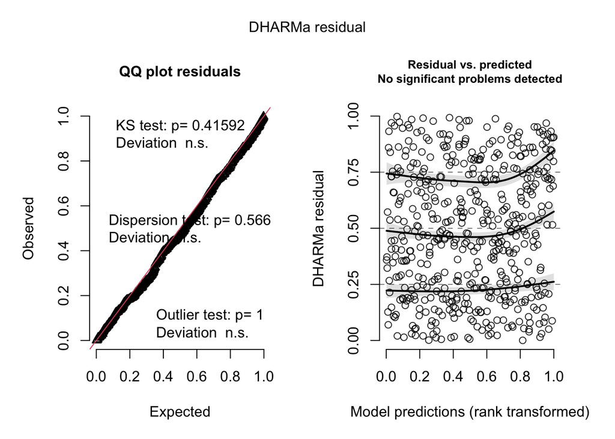

```r
ls.p7_sr <- simulateResiduals(fittedModel = ls.p7, n = 1000, plot = TRUE)
```

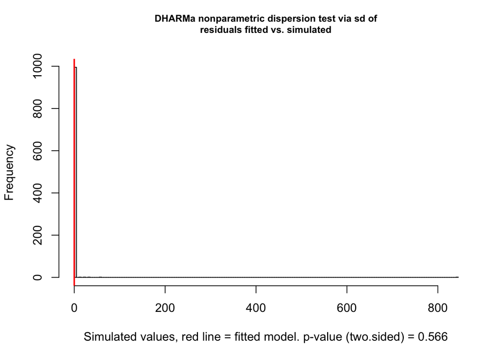

```
##
##  DHARMa nonparametric dispersion test via sd of residuals fitted vs.
##  simulated
##
## data:  simulationOutput
## dispersion = 0.000052329, p-value = 0.566
## alternative hypothesis: two.sided
```

```r
testDispersion(ls.p7_sr) #PASSES
```

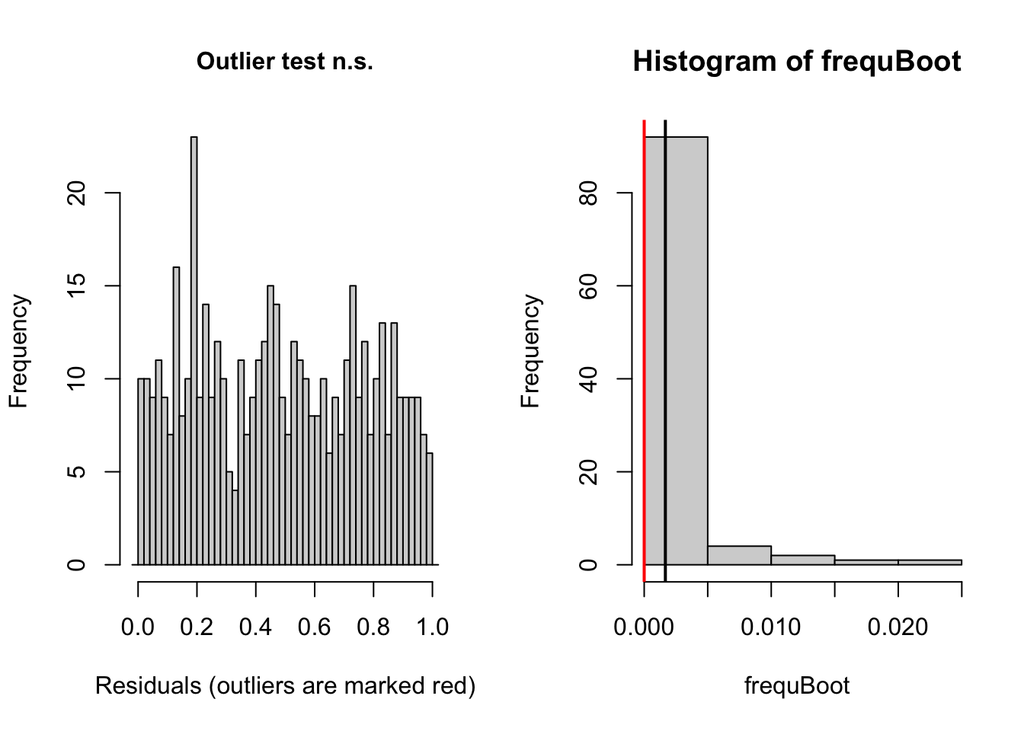

```
##
##  DHARMa bootstrapped outlier test
##
## data:  ls.p7_sr
## outliers at both margin(s) = 0, observations = 498, p-value = 1
## alternative hypothesis: two.sided
##  percent confidence interval:
##  0.00000000 0.01214859
## sample estimates:
## outlier frequency (expected: 0.00166666666666667 )
##                                                  0
```

```r
testOutliers(ls.p7_sr)
```

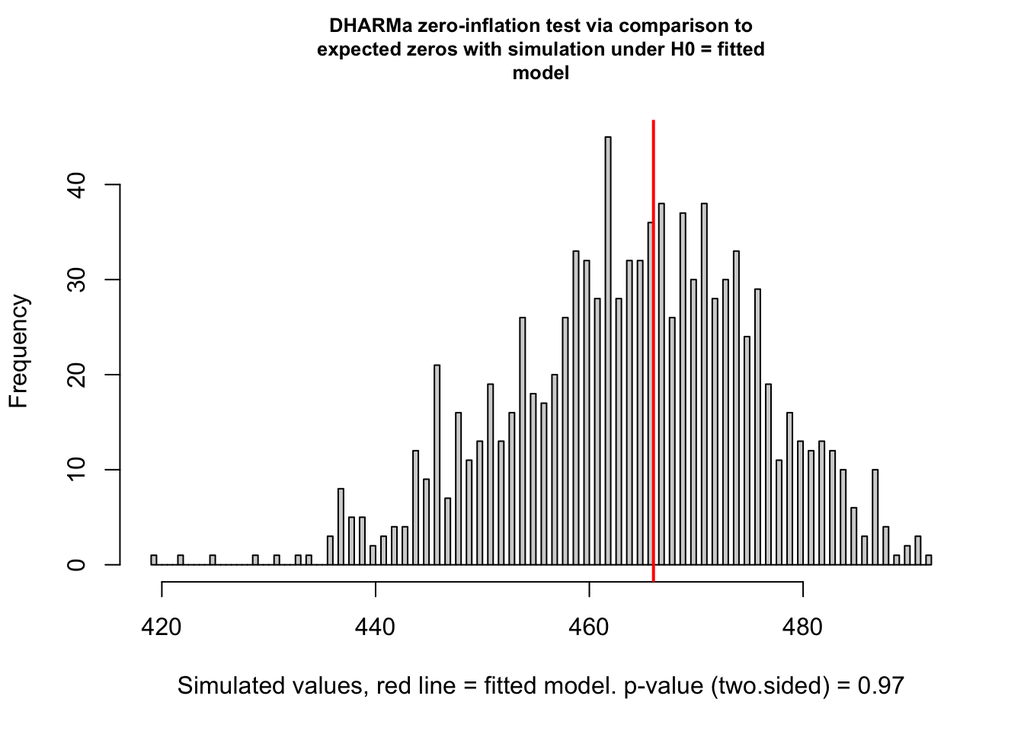

```
##
##  DHARMa zero-inflation test via comparison to expected zeros with
##  simulation under H0 = fitted model
##
## data:  simulationOutput
## ratioObsSim = 1.0037, p-value = 0.97
## alternative hypothesis: two.sided
```

```r
testZeroInflation(ls.p7_sr) #looks good
```

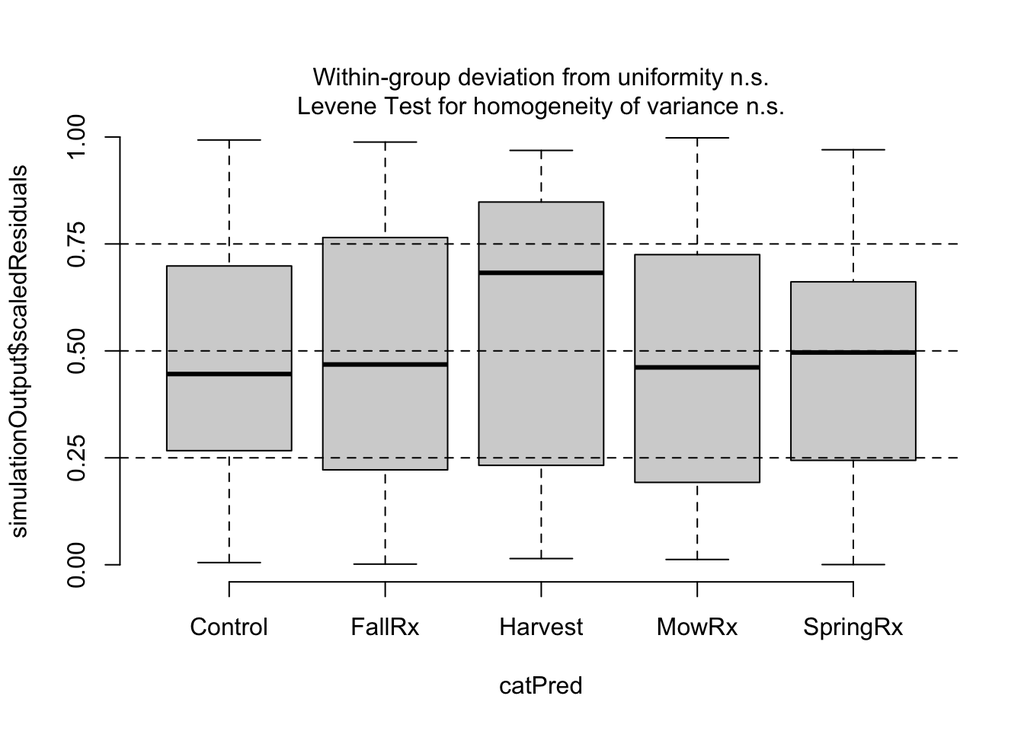

```r
# Plotting standardized residuals against predictors
plotResiduals(ls.p7_sr, ls_alldata$Treat_Type, xlab = "Treatment Type", main=NULL)
```

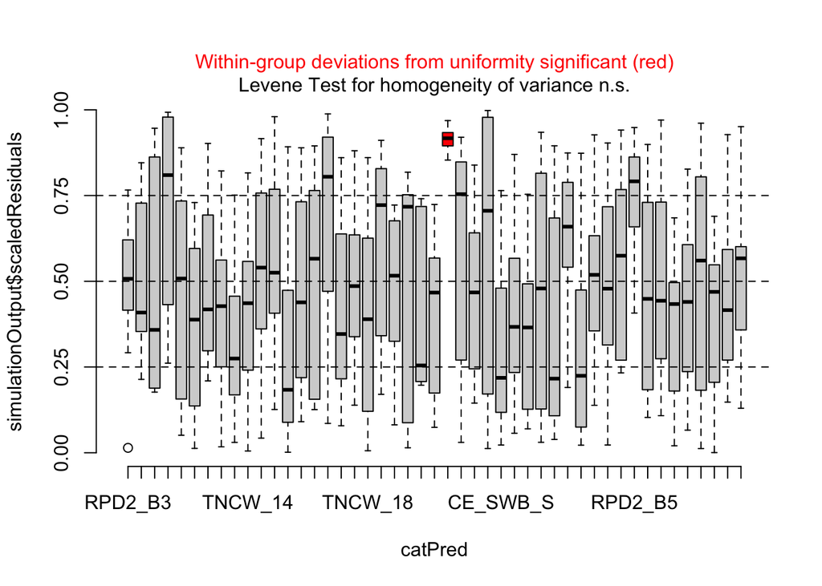

```r
plotResiduals(ls.p7_sr, ls_alldata$Site, xlab = "Site", main=NULL)
```

Use emmeans for pairwise comparison of Treatment Types:

```r
emmeans(ls.p7, specs = pairwise ~ Treat_Type, adjust = 'Tukey', type = 'response')
```

```
## $emmeans
##  Treat_Type     rate       SE  df  asymp.LCL asymp.UCL
##  Control    0.000169 0.000292 Inf 0.00000565   0.00503
##  FallRx     0.002913 0.004627 Inf 0.00012960   0.06549
##  Harvest    0.053498 0.089434 Inf 0.00202005   1.41681
##  MowRx      0.001469 0.002266 Inf 0.00007155   0.03018
##  SpringRx   0.002604 0.004432 Inf 0.00009266   0.07317
##
## Confidence level used: 0.95
## Intervals are back-transformed from the log scale
##
## $contrasts
##  contrast              ratio       SE  df null z.ratio p.value
##  Control / FallRx    0.05784  0.10925 Inf    1  -1.509  0.5566
##  Control / Harvest   0.00315  0.00646 Inf    1  -2.809  0.0398
##  Control / MowRx     0.11468  0.21188 Inf    1  -1.172  0.7674
##  Control / SpringRx  0.06472  0.13697 Inf    1  -1.294  0.6952
##  FallRx / Harvest    0.05446  0.10551 Inf    1  -1.502  0.5611
##  FallRx / MowRx      1.98264  3.42669 Inf    1   0.396  0.9948
##  FallRx / SpringRx   1.11882  2.24448 Inf    1   0.056  1.0000
##  Harvest / MowRx    36.40763 69.34496 Inf    1   1.887  0.3241
##  Harvest / SpringRx 20.54508 43.83454 Inf    1   1.417  0.6168
##  MowRx / SpringRx    0.56431  1.10094 Inf    1  -0.293  0.9984
##
## P value adjustment: tukey method for comparing a family of 5 estimates
## Tests are performed on the log scale
```

```r
# harvest is the only significantly different
```

Below is script to create plots. Do not run unless desired. The added packages cause issues for running general GLMM scripts (issues with tidyverse) and therefore are only worth activating if you want to produce graphs or have already loaded all desired analysis

```r
library(sjPlot)
library(sjlabelled)
library(sjmisc)

set_theme(base = theme_classic(),
          theme.font = 'serif',
          axis.title.size = 1.5,
          axis.textsize.x = 1.5,
          axis.textsize.y = 1.5,
          title.size = 2.5,
          title.align = "center",
          legend.pos = "right",
          legend.size = 1.5,
          legend.title.size = 1.5,
          #legend.bordercol = "black",
          legend.item.size = .75)

# LS plot 1 -------------------
plot_model(ls.p9,
           type = 'pred',
           terms = c('l.avgLD', 'Treat_Type'),
           axis.title = c("Average Leaf Litter Depth (log transformed)", "Total Count of Pitch Pine"),
           title = "Predicted Counts of Pitch Pine Seedlings \n >/=50cm & <2.5cm DBH",
           legend.title = "Treatment Type",
           line.size = 1,
           value.offset = 'Treat_Type',
           ci.lvl = NA,
           colors = c("#D8B70A", "#02401B", "#A2A475", "#81A88D", "#972D15"))
```

# Other hidden analysis: early data exploration, stats, and graphs

# Other hidden analysis: early models